# 動物實驗設計與研究方法

Week 04｜研究問題、研究目的與主要觀察指標

陳敬元 Jing-Yuan Chen, DVM, PhD

jychen@niar.org.tw

國家實驗研究院國家生物模式中心

宜蘭大學生物技術與動物科學系

October 1, 2026

# Anchor Papers

## 目前的 Anchor papers

| 目前呈現的研究角色 | 篇數 | Paper 中的主要研究情境 |
| --- | --- | --- |
| 目標物種的動物實驗 | 3 | 肉雞飼糧與益生菌；日本青鱂與大肚魚的水溫、存活與互動試驗 |
| 以動物代理其他目標情境 | 4 | Parkinson’s disease、肥胖、肝損傷與痛風性關節炎小鼠研究 |
| 動物來源材料研究 | 1 | 免疫蛋雞產製與純化 IgY |
| 觀察性動物研究 | 1 | 商業肉豬屠體與肉品質資料 |

依各篇論文的主要研究問題與推論對象分類。

## 不同研究情境，可以討論什麼？

| 研究情境 | 我們可以討論什麼？ |
| --- | --- |
| 肉雞飼糧、益生菌試驗 | 處置與對照能否回答研究問題？ 量測結果是否支持效果判斷？ |
| 小鼠疾病與代謝模式 | 模式對應哪個目標情境？ 結果支持多大的機制或應用結論？ |
| 日本青鱂與大肚魚的水溫與互動研究 | 接近行為與存活結果， 能支持哪些物種互動的解釋？ |
| 蛋雞 IgY 研究 | 免疫、抗體產製與萃取比較， 是否支持研究目的？ |
| 肉豬屠體觀察研究 | 觀察到的關聯能回答什麼？ 哪些因果結論仍缺乏支持？ |

我們可以依研究目的，探討動物使用、研究設計與結論是否相符。

## 動物實驗與動物模式

| 判斷面向 | 要問的問題 | 主要用途 |
| --- | --- | --- |
| **研究操作** | 研究者是否主動對動物分派或施加處置？ | 判斷是否屬於動物實驗 |
| **推論角色** | 動物本身是研究目標，還是代理另一個疾病、生理或應用情境？ | 判斷是否具有動物模式角色 |

- 使用動物，不代表一定是「動物模式」
- 沒有主動介入，也仍可能是重要的動物研究。

確認每篇 paper **在問什麼、取得什麼 outcome，以及結論能走到哪裡** 也是非常重要的！

# 01｜從證據邊界回到研究問題

## 今天要完成三件事

1. 分清研究問題、研究目的、假說與觀察指標各自負責什麼
2. 判斷研究是在探索線索，還是檢驗預先提出的假說
3. 用自己的 anchor paper 說出有證據支持的閱讀判斷

[figure not shown]

## 研究邏輯的延伸

| 週次 | 閱讀與判斷任務 |
| --- | --- |
| **Week 1** | 這篇研究問什麼、做了什麼、得到什麼結果？ |
| **Week 2** | 為什麼需要使用動物？研究設計是否支持其科學與倫理理由？ |
| **Week 3** | Model 與研究條件能支持多大的結論？ |
| **Week 4** | 研究問題、研究目的、觀察指標與結論是否前後一致？ |

## 上一週整理出來的的兩句話

> 本研究在＿＿條件下，可以支持關於＿＿的結論。

> 本研究不能直接推論＿＿，因為＿＿。

今天接著討論：

> **作者原本想要回答什麼？實際取得的結果，足以回答到哪裡？**

## 單一研究在開始前，需要先對齊什麼？

[figure not shown]

依據 Farrugia P, et al. *Can J Surg.* 2010;53(4):278–281. [PMCID: PMC2912019](https://pmc.ncbi.nlm.nih.gov/articles/PMC2912019/) 整理。

## 科學問題的循環與累積

- 研究從既有證據出發
- 找出尚未釐清之處
- 形成可回答的問題與  
  研究目的
- 新結果成為下一輪的證據

[figure not shown]

## 課堂案例 | 從研究領域到可回答的問題

| 層次 | 閱讀時要注意 | 課堂案例 |
| --- | --- | --- |
| 研究領域 (topic) | 研究關注哪個範圍？ | 肉豬跛行與自家疫苗 |
| 知識缺口 (knowledge gap) | 缺少哪一項證據？ | 商業豬場條件下的疫苗效果仍不確定 |
| 科學問題 (scientific problem) | 這個未知會影響什麼？ | 無法判斷疫苗是否能降低現場治療需求 |
| 研究問題 (research question) | 這項研究想回答什麼？ | 接種自家疫苗是否能夠降低因跛行接受治療的比例？ |

- 收斂的方向：研究範圍 → 未知 → 科學後果 → 一次研究可取得的證據

Maaland MG, Oropeza-Moe M. *Porcine Health Manag.* 2026. [doi:10.1186/s40813-026-00503-7](https://doi.org/10.1186/s40813-026-00503-7)

## 換一個案例｜哪一句已經是可回答的研究問題？

**情境設定：實驗動物福祉與行為（以囓齒類為例）**

- 哪一個說法才真正具備「可被單一實驗回答」的規格？

| 說法 | 判斷 |
| --- | --- |
| 我想研究動物緊迫 | 只有研究領域，範圍仍太廣 |
| 尚未有人使用 RNA-seq 研究這個主題 | 只指出方法尚未使用 |
| 兩種 housing conditions 出現不同結果，但原因仍不清楚 | 已指出待釐清的科學問題 |
| 在群體組成相同時，增加環境刺激是否降低攻擊行為？ | 已形成可回答的研究問題 |

- 重點不是句子有沒有問號/句號，是在於能否指向研究條件、比較與準備觀察的結果。

# 02｜研究邏輯的串連

Question → Objective → Primary Outcome → Conclusion

## 進入真實案例｜小鼠福祉與攻擊行為

**實驗動物房常見：**

`雄性小鼠群養時常有嚴重的攻擊爭鬥與咬傷。`

- 提供環境豐富化 (Enrichment) 究竟會：
  - 滿足遮蔽與築巢本能、降低攻擊？
  - 還是誘發領域資源爭奪、打得更兇？

為了釐清這件事，設計對照試驗：

- **對照組**：標準籠飼 (無豐富化)
- **豐富化組 (Enriched housing)**：
  - **築巢材料組**：Kleenex 面紙（築巢與遮蔽）
  - **避難筒組**：The Utrecht Shelter（躲避空間）

Van Loo PLP, et al. *Appl Anim Behav Sci.* 2002. doi:10.1016/S0168-1591(01)00200-3

研究問題→研究目的→主要指標→推論結論

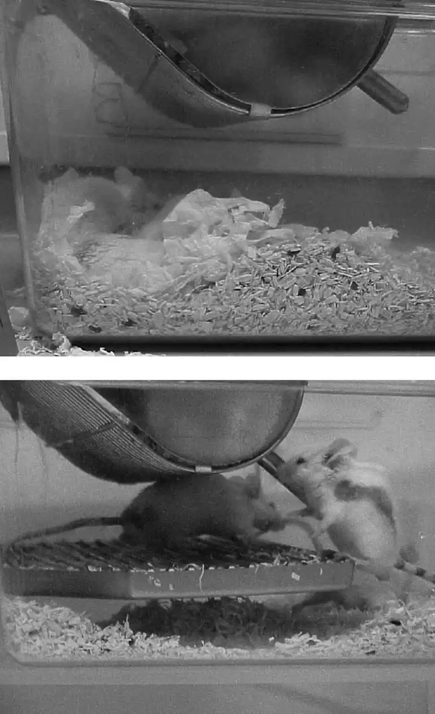

## 研究問題與研究目的

研究問題→研究目的→主要指標→推論結論

研究問題

`想知道什麼？`

**在群體組成相同時，提供環境豐富化是否降低雄性小鼠的攻擊行為？**

→

為了回答

研究目的

`研究準備完成什麼？`

**比較築巢材料組、避難筒組與對照組在換籠及重新合籠後的爭鬥行為。**

- **為了回答＿＿＿＿，本研究將＿＿＿＿。**
- 為了回答「**環境豐富化能否降低爭鬥**」，本研究將「**比較各組在換籠與合籠後的爭鬥行為**」。

研究目的不是寫想做什麼實驗 (例如跑行為影像分析)，  
而是寫準備如何回答那個問題。

## 研究任務決定是否需要假說

**探索型 (Exploratory)** ｜ 案發現場採跡證  
找關聯與線索，**不需預設方向性假說**。

**驗證型 (Hypothesis-testing)** ｜ 檢察官起訴定罪  
嚴格因果驗證，**實驗前必須對齊主要指標**。

| 研究任務 | 小鼠行為範例 | 事前承諾 |
| --- | --- | --- |
| **描述現象** *Descriptive* | 攻擊行為如何隨週數變化？ | 定義觀察變項與時間軸 |
| **探索關係** *Exploratory* | 哪些生理指標（皮質酮、體重）與打架相關？ | 摸索出的關聯只算「候選假說」 |
| **檢驗命題** *Hypothesis-testing* | 增加築巢材料是否降低爭鬥頻率？ | **事前鎖定 Primary outcome 與比較組** |

先確認研究任務，才知道數據是在考驗假說，還是產生線索。

[Van Loo PLP, et al. *Appl Anim Behav Sci.* 2002.](https://www.sciencedirect.com/science/article/abs/pii/S0168159101002003) Kimmelman J, et al. *PLoS Biol.* 2014. Percie du Sert N, et al. *PLoS Biol.* 2020.

## Primary outcome 與主要研究問題

研究問題→研究目的→主要指標→推論結論

主要研究問題

**增加築巢材料是否降低雄性小鼠的爭鬥行為？**

→

直接回答

Primary outcome

**例行換籠後，每組在觀察期內發生的爭鬥頻率與持續時間**  
*(Agonistic encounters: frequency & duration)*

**選定 Primary outcome 的依據：能否直接回答主要研究問題。**

在事前指定主要指標的驗證型研究中，通常以該指標的預期效果量與變異作為樣本數估算的主要依據。

Van Loo PLP, et al. *Appl Anim Behav Sci.* 2002.

## Outcome 限制可支持的結論

研究問題→研究目的→主要指標→推論結論

可以支持

- **築巢材料 (Nesting material)**：相較於避難筒組，顯著降低體表咬傷與整體攻擊傷害
- **避難筒 (Shelter)**：在此條件下未達預期，反而伴隨更多攻擊傷害（可能因空間結構阻礙逃生）

不能單獨支持

- “環境豐富化必然有益於小鼠福祉” (不同道具效果完全相反)
- 雌性小鼠或其他攻擊性較低的品系 (如 C57BL/6) 也會有相同反應
- 長期未換籠或其他群體大小下的攻擊變化
- 結論應停留在實驗量測的條件與指標邊界內；不能把單一的局部數據，外推成廣泛適用的通則。

Van Loo PLP, et al. *Appl Anim Behav Sci.* 2002. [doi:10.1016/S0168-1591(01)00200-3](https://www.sciencedirect.com/science/article/abs/pii/S0168159101002003)

## 休息 10 分鐘

休息後：

拉扯研究鏈，進行 Alignment Audit

# 03｜研究鏈的對齊檢驗

Alignment audit: 抓出推論中的膨脹、過度外推與邏輯斷點

## 正面示範｜豬場自家疫苗案例的安全對齊

| 元素 | 依 paper 重建的內容 |
| --- | --- |
| **Question** | 自家疫苗是否降低因跛行接受治療的比例？ |
| **Objective** | 比較疫苗組與安慰劑組的跛行治療比例 |
| **主要 outcome** | 各組因跛行接受 tiamulin 治療的豬隻比例 |
| **Result** | 7.8% vs. 6.8%；*p* = 0.354（未達顯著差異） |
| **可支持的 conclusion** | 在這項單一豬場試驗條件下，未觀察到治療率下降 |

**安全對齊：**主要 outcome 測量跛行治療比例，因此 conclusion 只停在「未觀察到該比例下降」，不外推到其他豬場或全方位抗病力。

Maaland MG, Oropeza-Moe M. *Porcine Health Manag.* 2026. [doi:10.1186/s40813-026-00503-7](https://doi.org/10.1186/s40813-026-00503-7)

## 反面抓碴｜哪裡沒有對齊？

> **Scientific problem**：疫苗保護能否維持到生產後期？

> **Objective**：比較接種後一週的抗體濃度。

> **Outcome**：接種後一週的血清抗體濃度。

> **Conclusion**：疫苗可提供整個生產期的持續保護。

請找出至少兩個邏輯斷點。

## 解答｜研究鏈的兩個斷點

**斷點一｜時間斷裂**

Question 問的是：

> 保護能否維持到生產後期？

Outcome 卻只測到：

> 接種後一週

**斷點二｜推論膨脹**

Outcome 測量：

> 抗體濃度（surrogate）

Conclusion 卻宣稱：

> 持續的臨床保護力

時間不能自行延長，只有部份採樣的動物實驗結果  
也不適合升級推論成臨床效果。

## 反面抓碴 (二)｜換成小鼠福祉評估，哪裡沒有對齊？

- **Scientific problem**：提供避難設施 (The Utrecht Shelter) 是否能增進雄性小鼠福祉並降低攻擊爭鬥？
- **Objective**：評估小鼠在籠內使用避難筒的偏好與進出頻率。
- **Outcome**：例行換籠後，小鼠進入避難筒的累積時間（Occupancy time）。
- **Conclusion**：證實避難筒能顯著改善小鼠福祉，推薦作為標準飼養配備。

大家覺得問題點在哪裡？

## 解答 (二)｜小鼠研究鏈的兩個斷點

斷點一 ｜ 表徵推論膨脹

**Outcome 測量：**  
躲在避難筒的累積時間（使用偏好）

**Conclusion 卻宣稱：**  
增進整體福祉、降低攻擊爭鬥

> 待在筒子裡可能只是無處可逃或強勢鼠霸佔資源，不能把「使用道具」等同於「心理福祉」。

斷點二 ｜ 忽略核心傷害指標

**Question 問的是：**  
能否降低攻擊爭鬥？

**Outcome 卻避開了：**  
爭鬥次數與體表咬傷

> 真實文獻（Van Loo 2002）指出：避難筒因缺乏逃生出口，反而導致爭鬥與尾巴咬傷加劇！
- 不能用單一的使用表徵，掩蓋真實的傷害指標
- 更不能把動物的無奈選擇當成福祉改善。

## Alignment Audit｜邏輯對齊檢核清單

**問句一｜指標本質**  
這個指標真的是核心想看的事實，還是只是便宜、好量測的替代品？

**問句二｜推論邊界**  
作者在 Discussion 有沒有偷偷把時間拉長、群體放大，或把「替代指標」升級成全面結論？

四步檢核鏈： 問題 ↔︎ 目的 → 目的 ↔︎ 指標 → 假說 ↔︎ 分析 → 指標 ↔︎ 結論

# 04｜檢驗 Anchor Paper

三句話檢驗：檢驗 Question ↔︎ Primary Outcome ↔︎ Conclusion

## 三句話檢驗 Anchor Paper

> **第一句｜這篇論文宣稱要解決的 Question 是：＿＿＿＿。**

> **第二句｜作者真正在統計與方法中指定的 Primary Outcome 是：＿＿＿＿。**

> **第三句｜我認為他的結論【有／沒有】對齊，因為＿＿＿＿。**

請在 paper 中找支持判斷的 methods、主要圖表或 discussion；若作者未明確指定 primary outcome，直接說「未明確指定」。

- 請大家分享一下

## 三種常見翻車

1. **把技術方法當作研究目的**  
   例如：「我的目的是跑 RNA-seq。」
2. **找不出哪一個才是作者指定的 Primary Outcome**
3. **被 Discussion 的延伸推論帶走**  
   忘記回頭確認數據實際量測了什麼。

## Week 05 的起點

今天已經確認：

- 研究準備回答什麼問題
- 哪個 outcome 提供主要判斷依據
- 結論應停在哪個範圍

下週接著問：

> **Intervention 或 condition 實際施加在哪個單位？**  
> **Outcome 又從哪一個層級取得？**

## 本週核心參考資料

- Farrugia P, Petrisor BA, Farrokhyar F, Bhandari M. 2010. Research questions, hypotheses and objectives. *Canadian Journal of Surgery* 53:278–281. PMCID: PMC2912019.
- Kimmelman J, Mogil JS, Dirnagl U. 2014. Distinguishing between exploratory and confirmatory preclinical research will improve translation. *PLoS Biology* 12:e1001863. doi:10.1371/journal.pbio.1001863.
- Percie du Sert N, et al. 2020. Reporting animal research: Explanation and elaboration for the ARRIVE guidelines 2.0. *PLoS Biology* 18:e3000411. doi:10.1371/journal.pbio.3000411.
- Maaland MG, Oropeza-Moe M. 2026. Randomized controlled single-farm field evaluation of an autogenous *Mycoplasma hyosynoviae* bacterin. *Porcine Health Management*. doi:10.1186/s40813-026-00503-7.

## 動物實驗規劃參考資料

- Smith AJ, et al. 2018. PREPARE: guidelines for planning animal research and testing. *Laboratory Animals* 52:135–141. doi:10.1177/0023677217724823.
- Karp NA, Fry D. 2021. What is the optimum design for my animal experiment? *BMJ Open Science* 5:e100126. doi:10.1136/bmjos-2020-100126.
- Festing MFW, Altman DG. 2002. Guidelines for the design and statistical analysis of experiments using laboratory animals. *ILAR Journal* 43:244–258.
- De Cuyper C, Ampe B, Westin R, van Milgen J, Millet S. 2025. Improving experimental design in animal research: seven key principles. *Animal* 19:101695. doi:10.1016/j.animal.2025.101695.